# Risk Factor Analysis

## Outcome Variable

**Outcome Variable:** ever_swasted

## Predictor Variables

**Intervention Variable:** hfoodsec

**Adjustment Set:**

- arm
- sex
- W_mage
- meducyrs
- feducyrs
- hhwealth_quart
- vagbrth
- W_nrooms
- W_nchldlt5
- brthmon
- W_parity
- impfloor
- impsan
- safeh20
- delta_W_mage
- delta_meducyrs
- delta_feducyrs
- delta_hhwealth_quart
- delta_vagbrth
- delta_W_nrooms
- delta_W_nchldlt5
- delta_brthmon
- delta_W_parity
- delta_impfloor
- delta_impsan
- delta_safeh20

## Stratifying Variables

The analysis was stratified on these variable(s):

- agecat
- studyid
- country

## Data Summary

| agecat | studyid | country | hfoodsec | ever_swasted | n_cell | n |
| --- | --- | --- | --- | --- | --- | --- |
| 0-24 months | ki0047075b-MAL-ED | BANGLADESH | Food Secure | 0 | 146 | 194 |
| 0-24 months | ki0047075b-MAL-ED | BANGLADESH | Food Secure | 1 | 15 | 194 |
| 0-24 months | ki0047075b-MAL-ED | BANGLADESH | Mildly Food Insecure | 0 | 4 | 194 |
| 0-24 months | ki0047075b-MAL-ED | BANGLADESH | Mildly Food Insecure | 1 | 0 | 194 |
| 0-24 months | ki0047075b-MAL-ED | BANGLADESH | Food Insecure | 0 | 26 | 194 |
| 0-24 months | ki0047075b-MAL-ED | BANGLADESH | Food Insecure | 1 | 3 | 194 |
| 0-24 months | ki0047075b-MAL-ED | BRAZIL | Food Secure | 0 | 3 | 129 |
| 0-24 months | ki0047075b-MAL-ED | BRAZIL | Food Secure | 1 | 0 | 129 |
| 0-24 months | ki0047075b-MAL-ED | BRAZIL | Mildly Food Insecure | 0 | 11 | 129 |
| 0-24 months | ki0047075b-MAL-ED | BRAZIL | Mildly Food Insecure | 1 | 0 | 129 |
| 0-24 months | ki0047075b-MAL-ED | BRAZIL | Food Insecure | 0 | 113 | 129 |
| 0-24 months | ki0047075b-MAL-ED | BRAZIL | Food Insecure | 1 | 2 | 129 |
| 0-24 months | ki0047075b-MAL-ED | INDIA | Food Secure | 0 | 170 | 212 |
| 0-24 months | ki0047075b-MAL-ED | INDIA | Food Secure | 1 | 20 | 212 |
| 0-24 months | ki0047075b-MAL-ED | INDIA | Mildly Food Insecure | 0 | 3 | 212 |
| 0-24 months | ki0047075b-MAL-ED | INDIA | Mildly Food Insecure | 1 | 2 | 212 |
| 0-24 months | ki0047075b-MAL-ED | INDIA | Food Insecure | 0 | 16 | 212 |
| 0-24 months | ki0047075b-MAL-ED | INDIA | Food Insecure | 1 | 1 | 212 |
| 0-24 months | ki0047075b-MAL-ED | NEPAL | Food Secure | 0 | 92 | 128 |
| 0-24 months | ki0047075b-MAL-ED | NEPAL | Food Secure | 1 | 2 | 128 |
| 0-24 months | ki0047075b-MAL-ED | NEPAL | Mildly Food Insecure | 0 | 14 | 128 |
| 0-24 months | ki0047075b-MAL-ED | NEPAL | Mildly Food Insecure | 1 | 1 | 128 |
| 0-24 months | ki0047075b-MAL-ED | NEPAL | Food Insecure | 0 | 18 | 128 |
| 0-24 months | ki0047075b-MAL-ED | NEPAL | Food Insecure | 1 | 1 | 128 |
| 0-24 months | ki0047075b-MAL-ED | PERU | Food Secure | 0 | 26 | 113 |
| 0-24 months | ki0047075b-MAL-ED | PERU | Food Secure | 1 | 1 | 113 |
| 0-24 months | ki0047075b-MAL-ED | PERU | Mildly Food Insecure | 0 | 29 | 113 |
| 0-24 months | ki0047075b-MAL-ED | PERU | Mildly Food Insecure | 1 | 0 | 113 |
| 0-24 months | ki0047075b-MAL-ED | PERU | Food Insecure | 0 | 55 | 113 |
| 0-24 months | ki0047075b-MAL-ED | PERU | Food Insecure | 1 | 2 | 113 |

[output cut: 168 more lines]

The following strata were considered:

- agecat: 0-24 months, studyid: ki0047075b-MAL-ED, country: BANGLADESH
- agecat: 0-24 months, studyid: ki0047075b-MAL-ED, country: BRAZIL
- agecat: 0-24 months, studyid: ki0047075b-MAL-ED, country: INDIA
- agecat: 0-24 months, studyid: ki0047075b-MAL-ED, country: NEPAL
- agecat: 0-24 months, studyid: ki0047075b-MAL-ED, country: PERU
- agecat: 0-24 months, studyid: ki0047075b-MAL-ED, country: SOUTH AFRICA
- agecat: 0-24 months, studyid: ki1017093-NIH-Birth, country: BANGLADESH
- agecat: 0-24 months, studyid: ki1017093c-NIH-Crypto, country: BANGLADESH
- agecat: 0-24 months, studyid: ki1113344-GMS-Nepal, country: NEPAL
- agecat: 0-24 months, studyid: kiGH5241-JiVitA-3, country: BANGLADESH
- agecat: 0-24 months, studyid: kiGH5241-JiVitA-4, country: BANGLADESH
- agecat: 0-6 months, studyid: ki0047075b-MAL-ED, country: BANGLADESH
- agecat: 0-6 months, studyid: ki0047075b-MAL-ED, country: BRAZIL
- agecat: 0-6 months, studyid: ki0047075b-MAL-ED, country: INDIA
- agecat: 0-6 months, studyid: ki0047075b-MAL-ED, country: NEPAL
- agecat: 0-6 months, studyid: ki0047075b-MAL-ED, country: PERU
- agecat: 0-6 months, studyid: ki0047075b-MAL-ED, country: SOUTH AFRICA
- agecat: 0-6 months, studyid: ki1017093-NIH-Birth, country: BANGLADESH
- agecat: 0-6 months, studyid: ki1017093c-NIH-Crypto, country: BANGLADESH
- agecat: 0-6 months, studyid: ki1113344-GMS-Nepal, country: NEPAL
- agecat: 0-6 months, studyid: kiGH5241-JiVitA-3, country: BANGLADESH
- agecat: 0-6 months, studyid: kiGH5241-JiVitA-4, country: BANGLADESH
- agecat: 6-24 months, studyid: ki0047075b-MAL-ED, country: BANGLADESH
- agecat: 6-24 months, studyid: ki0047075b-MAL-ED, country: BRAZIL
- agecat: 6-24 months, studyid: ki0047075b-MAL-ED, country: INDIA
- agecat: 6-24 months, studyid: ki0047075b-MAL-ED, country: NEPAL
- agecat: 6-24 months, studyid: ki0047075b-MAL-ED, country: PERU
- agecat: 6-24 months, studyid: ki0047075b-MAL-ED, country: SOUTH AFRICA
- agecat: 6-24 months, studyid: ki1017093-NIH-Birth, country: BANGLADESH
- agecat: 6-24 months, studyid: ki1017093c-NIH-Crypto, country: BANGLADESH
- agecat: 6-24 months, studyid: ki1113344-GMS-Nepal, country: NEPAL
- agecat: 6-24 months, studyid: kiGH5241-JiVitA-3, country: BANGLADESH
- agecat: 6-24 months, studyid: kiGH5241-JiVitA-4, country: BANGLADESH

### Dropped Strata

Some strata were dropped due to rare outcomes:

- agecat: 0-24 months, studyid: ki0047075b-MAL-ED, country: BANGLADESH
- agecat: 0-24 months, studyid: ki0047075b-MAL-ED, country: BRAZIL
- agecat: 0-24 months, studyid: ki0047075b-MAL-ED, country: INDIA
- agecat: 0-24 months, studyid: ki0047075b-MAL-ED, country: NEPAL
- agecat: 0-24 months, studyid: ki0047075b-MAL-ED, country: PERU
- agecat: 0-24 months, studyid: ki0047075b-MAL-ED, country: SOUTH AFRICA
- agecat: 0-6 months, studyid: ki0047075b-MAL-ED, country: BANGLADESH
- agecat: 0-6 months, studyid: ki0047075b-MAL-ED, country: BRAZIL
- agecat: 0-6 months, studyid: ki0047075b-MAL-ED, country: INDIA
- agecat: 0-6 months, studyid: ki0047075b-MAL-ED, country: NEPAL
- agecat: 0-6 months, studyid: ki0047075b-MAL-ED, country: PERU
- agecat: 0-6 months, studyid: ki0047075b-MAL-ED, country: SOUTH AFRICA
- agecat: 0-6 months, studyid: ki1017093c-NIH-Crypto, country: BANGLADESH
- agecat: 6-24 months, studyid: ki0047075b-MAL-ED, country: BANGLADESH
- agecat: 6-24 months, studyid: ki0047075b-MAL-ED, country: BRAZIL
- agecat: 6-24 months, studyid: ki0047075b-MAL-ED, country: INDIA
- agecat: 6-24 months, studyid: ki0047075b-MAL-ED, country: NEPAL
- agecat: 6-24 months, studyid: ki0047075b-MAL-ED, country: PERU
- agecat: 6-24 months, studyid: ki0047075b-MAL-ED, country: SOUTH AFRICA
- agecat: 6-24 months, studyid: ki1017093-NIH-Birth, country: BANGLADESH
- agecat: 6-24 months, studyid: ki1017093c-NIH-Crypto, country: BANGLADESH

## Methods Detail

We’re interested in the causal parameters $E[Y_a]$ for all values of $a \in \mathcal{A}$. These parameters represent the mean outcome if, possibly contrary to fact, we intervened to set all units to have $A=a$. Under the randomization and positivity assumptions, these are identified by the statistical parameters $\psi_a=E_W[E_{Y|A,W}(Y|A=a,W)]$. In addition, we’re interested in the mean of $Y$, $E[Y]$ under no intervention (the observed mean). We will estimate these parameters by using SuperLearner to fit the relevant likelihood factors – $E_{Y|A,W}(Y|A=a,W)$ and $p(A=a|W)$, and then updating our likelihood fit using a joint TMLE.

For unadjusted analyses ($W=\{\}$), initial likelihoods were estimated using Lrnr_glm to estimate the simple $E(Y|A)$ and Lrnr_mean to estimate $p(A)$. For adjusted analyses, a small library containing Lrnr_glmnet, Lrnr_xgboost, and Lrnr_mean was used.

Having estimated these parameters, we will then use the delta method to estimate relative risks and attributable risks relative to a prespecified baseline level of $A$.

# Results Detail

## Results Plots

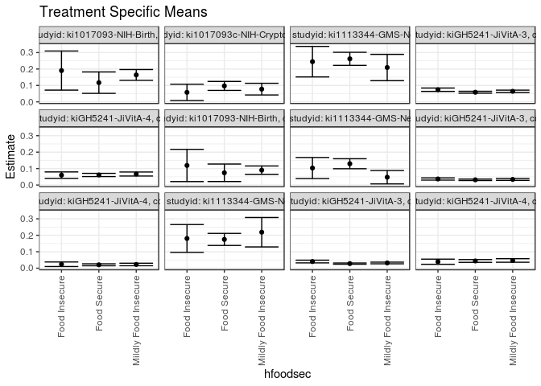

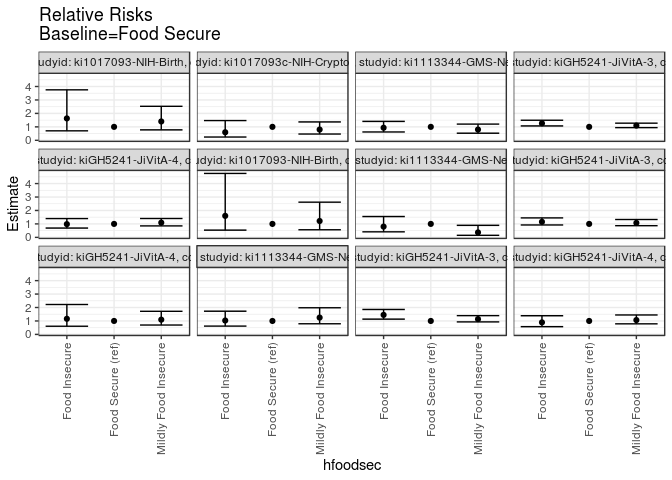

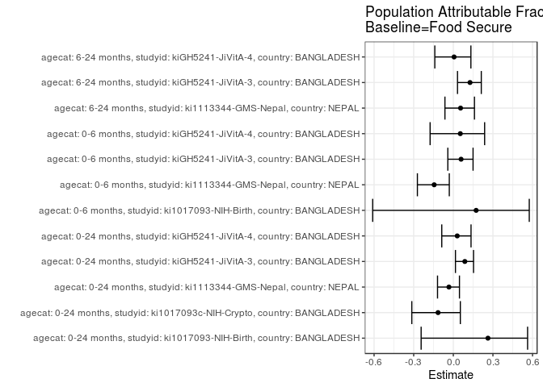

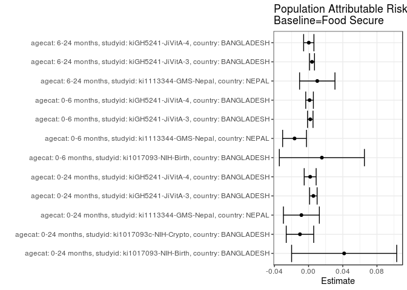

## Results Table

### Parameter: TSM

| agecat | studyid | country | intervention_level | baseline_level | estimate | ci_lower | ci_upper |
| --- | --- | --- | --- | --- | --- | --- | --- |
| 0-24 months | ki1017093-NIH-Birth | BANGLADESH | Food Secure | NA | 0.1170213 | 0.0519874 | 0.1820552 |
| 0-24 months | ki1017093-NIH-Birth | BANGLADESH | Mildly Food Insecure | NA | 0.1639344 | 0.1310612 | 0.1968076 |
| 0-24 months | ki1017093-NIH-Birth | BANGLADESH | Food Insecure | NA | 0.1904762 | 0.0716241 | 0.3093283 |
| 0-24 months | ki1017093c-NIH-Crypto | BANGLADESH | Food Secure | NA | 0.0971302 | 0.0698420 | 0.1244185 |
| 0-24 months | ki1017093c-NIH-Crypto | BANGLADESH | Mildly Food Insecure | NA | 0.0776256 | 0.0421631 | 0.1130880 |
| 0-24 months | ki1017093c-NIH-Crypto | BANGLADESH | Food Insecure | NA | 0.0581395 | 0.0086499 | 0.1076292 |
| 0-24 months | ki1113344-GMS-Nepal | NEPAL | Food Secure | NA | 0.2617911 | 0.2219774 | 0.3016049 |
| 0-24 months | ki1113344-GMS-Nepal | NEPAL | Mildly Food Insecure | NA | 0.2090101 | 0.1289836 | 0.2890365 |
| 0-24 months | ki1113344-GMS-Nepal | NEPAL | Food Insecure | NA | 0.2446331 | 0.1517882 | 0.3374779 |
| 0-24 months | kiGH5241-JiVitA-3 | BANGLADESH | Food Secure | NA | 0.0586240 | 0.0527710 | 0.0644771 |
| 0-24 months | kiGH5241-JiVitA-3 | BANGLADESH | Mildly Food Insecure | NA | 0.0642195 | 0.0569519 | 0.0714870 |
| 0-24 months | kiGH5241-JiVitA-3 | BANGLADESH | Food Insecure | NA | 0.0740802 | 0.0638167 | 0.0843437 |
| 0-24 months | kiGH5241-JiVitA-4 | BANGLADESH | Food Secure | NA | 0.0612828 | 0.0515420 | 0.0710235 |
| 0-24 months | kiGH5241-JiVitA-4 | BANGLADESH | Mildly Food Insecure | NA | 0.0669437 | 0.0547702 | 0.0791171 |
| 0-24 months | kiGH5241-JiVitA-4 | BANGLADESH | Food Insecure | NA | 0.0601854 | 0.0406730 | 0.0796978 |
| 0-6 months | ki1017093-NIH-Birth | BANGLADESH | Food Secure | NA | 0.0744681 | 0.0213534 | 0.1275827 |
| 0-6 months | ki1017093-NIH-Birth | BANGLADESH | Mildly Food Insecure | NA | 0.0905350 | 0.0650032 | 0.1160667 |
| 0-6 months | ki1017093-NIH-Birth | BANGLADESH | Food Insecure | NA | 0.1190476 | 0.0210288 | 0.2170664 |
| 0-6 months | ki1113344-GMS-Nepal | NEPAL | Food Secure | NA | 0.1295117 | 0.0991657 | 0.1598577 |
| 0-6 months | ki1113344-GMS-Nepal | NEPAL | Mildly Food Insecure | NA | 0.0476190 | 0.0068550 | 0.0883831 |
| 0-6 months | ki1113344-GMS-Nepal | NEPAL | Food Insecure | NA | 0.1034483 | 0.0394062 | 0.1674904 |
| 0-6 months | kiGH5241-JiVitA-3 | BANGLADESH | Food Secure | NA | 0.0318593 | 0.0273779 | 0.0363406 |
| 0-6 months | kiGH5241-JiVitA-3 | BANGLADESH | Mildly Food Insecure | NA | 0.0341675 | 0.0283575 | 0.0399775 |
| 0-6 months | kiGH5241-JiVitA-3 | BANGLADESH | Food Insecure | NA | 0.0367729 | 0.0300743 | 0.0434714 |
| 0-6 months | kiGH5241-JiVitA-4 | BANGLADESH | Food Secure | NA | 0.0205910 | 0.0146359 | 0.0265462 |
| 0-6 months | kiGH5241-JiVitA-4 | BANGLADESH | Mildly Food Insecure | NA | 0.0225715 | 0.0149530 | 0.0301901 |
| 0-6 months | kiGH5241-JiVitA-4 | BANGLADESH | Food Insecure | NA | 0.0239269 | 0.0100942 | 0.0377595 |
| 6-24 months | ki1113344-GMS-Nepal | NEPAL | Food Secure | NA | 0.1748138 | 0.1380721 | 0.2115555 |
| 6-24 months | ki1113344-GMS-Nepal | NEPAL | Mildly Food Insecure | NA | 0.2186563 | 0.1291962 | 0.3081163 |
| 6-24 months | ki1113344-GMS-Nepal | NEPAL | Food Insecure | NA | 0.1806391 | 0.0961048 | 0.2651735 |
| 6-24 months | kiGH5241-JiVitA-3 | BANGLADESH | Food Secure | NA | 0.0278749 | 0.0240935 | 0.0316563 |
| 6-24 months | kiGH5241-JiVitA-3 | BANGLADESH | Mildly Food Insecure | NA | 0.0317611 | 0.0267022 | 0.0368200 |
| 6-24 months | kiGH5241-JiVitA-3 | BANGLADESH | Food Insecure | NA | 0.0404529 | 0.0322222 | 0.0486835 |
| 6-24 months | kiGH5241-JiVitA-4 | BANGLADESH | Food Secure | NA | 0.0439289 | 0.0355274 | 0.0523304 |
| 6-24 months | kiGH5241-JiVitA-4 | BANGLADESH | Mildly Food Insecure | NA | 0.0468259 | 0.0360987 | 0.0575531 |
| 6-24 months | kiGH5241-JiVitA-4 | BANGLADESH | Food Insecure | NA | 0.0392771 | 0.0235362 | 0.0550181 |

### Parameter: E(Y)

| agecat | studyid | country | intervention_level | baseline_level | estimate | ci_lower | ci_upper |
| --- | --- | --- | --- | --- | --- | --- | --- |
| 0-24 months | ki1017093-NIH-Birth | BANGLADESH | NA | NA | 0.1586538 | 0.1299648 | 0.1873429 |
| 0-24 months | ki1017093c-NIH-Crypto | BANGLADESH | NA | NA | 0.0870712 | 0.0669870 | 0.1071555 |
| 0-24 months | ki1113344-GMS-Nepal | NEPAL | NA | NA | 0.2533937 | 0.2202605 | 0.2865268 |
| 0-24 months | kiGH5241-JiVitA-3 | BANGLADESH | NA | NA | 0.0642302 | 0.0601218 | 0.0683386 |
| 0-24 months | kiGH5241-JiVitA-4 | BANGLADESH | NA | NA | 0.0631598 | 0.0562585 | 0.0700612 |
| 0-6 months | ki1017093-NIH-Birth | BANGLADESH | NA | NA | 0.0900322 | 0.0675202 | 0.1125442 |
| 0-6 months | ki1113344-GMS-Nepal | NEPAL | NA | NA | 0.1131222 | 0.0889940 | 0.1372504 |
| 0-6 months | kiGH5241-JiVitA-3 | BANGLADESH | NA | NA | 0.0338522 | 0.0307634 | 0.0369410 |
| 0-6 months | kiGH5241-JiVitA-4 | BANGLADESH | NA | NA | 0.0217434 | 0.0173381 | 0.0261487 |
| 6-24 months | ki1113344-GMS-Nepal | NEPAL | NA | NA | 0.1849913 | 0.1531708 | 0.2168118 |
| 6-24 months | kiGH5241-JiVitA-3 | BANGLADESH | NA | NA | 0.0319118 | 0.0290313 | 0.0347923 |
| 6-24 months | kiGH5241-JiVitA-4 | BANGLADESH | NA | NA | 0.0441886 | 0.0382741 | 0.0501032 |

### Parameter: RR

| agecat | studyid | country | intervention_level | baseline_level | estimate | ci_lower | ci_upper |
| --- | --- | --- | --- | --- | --- | --- | --- |
| 0-24 months | ki1017093-NIH-Birth | BANGLADESH | Food Secure | Food Secure | 1.0000000 | 1.0000000 | 1.0000000 |
| 0-24 months | ki1017093-NIH-Birth | BANGLADESH | Mildly Food Insecure | Food Secure | 1.4008942 | 0.7759210 | 2.5292582 |
| 0-24 months | ki1017093-NIH-Birth | BANGLADESH | Food Insecure | Food Secure | 1.6277056 | 0.7058100 | 3.7537375 |
| 0-24 months | ki1017093c-NIH-Crypto | BANGLADESH | Food Secure | Food Secure | 1.0000000 | 1.0000000 | 1.0000000 |
| 0-24 months | ki1017093c-NIH-Crypto | BANGLADESH | Mildly Food Insecure | Food Secure | 0.7991905 | 0.4674468 | 1.3663705 |
| 0-24 months | ki1017093c-NIH-Crypto | BANGLADESH | Food Insecure | Food Secure | 0.5985729 | 0.2442425 | 1.4669421 |
| 0-24 months | ki1113344-GMS-Nepal | NEPAL | Food Secure | Food Secure | 1.0000000 | 1.0000000 | 1.0000000 |
| 0-24 months | ki1113344-GMS-Nepal | NEPAL | Mildly Food Insecure | Food Secure | 0.7983848 | 0.5290464 | 1.2048439 |
| 0-24 months | ki1113344-GMS-Nepal | NEPAL | Food Insecure | Food Secure | 0.9344591 | 0.6208751 | 1.4064240 |
| 0-24 months | kiGH5241-JiVitA-3 | BANGLADESH | Food Secure | Food Secure | 1.0000000 | 1.0000000 | 1.0000000 |
| 0-24 months | kiGH5241-JiVitA-3 | BANGLADESH | Mildly Food Insecure | Food Secure | 1.0954458 | 0.9424264 | 1.2733106 |
| 0-24 months | kiGH5241-JiVitA-3 | BANGLADESH | Food Insecure | Food Secure | 1.2636484 | 1.0686989 | 1.4941602 |
| 0-24 months | kiGH5241-JiVitA-4 | BANGLADESH | Food Secure | Food Secure | 1.0000000 | 1.0000000 | 1.0000000 |
| 0-24 months | kiGH5241-JiVitA-4 | BANGLADESH | Mildly Food Insecure | Food Secure | 1.0923733 | 0.8515031 | 1.4013799 |
| 0-24 months | kiGH5241-JiVitA-4 | BANGLADESH | Food Insecure | Food Secure | 0.9820924 | 0.6902717 | 1.3972837 |
| 0-6 months | ki1017093-NIH-Birth | BANGLADESH | Food Secure | Food Secure | 1.0000000 | 1.0000000 | 1.0000000 |
| 0-6 months | ki1017093-NIH-Birth | BANGLADESH | Mildly Food Insecure | Food Secure | 1.2157554 | 0.5646124 | 2.6178337 |
| 0-6 months | ki1017093-NIH-Birth | BANGLADESH | Food Insecure | Food Secure | 1.5986395 | 0.5378468 | 4.7516283 |
| 0-6 months | ki1113344-GMS-Nepal | NEPAL | Food Secure | Food Secure | 1.0000000 | 1.0000000 | 1.0000000 |
| 0-6 months | ki1113344-GMS-Nepal | NEPAL | Mildly Food Insecure | Food Secure | 0.3676815 | 0.1513636 | 0.8931453 |
| 0-6 months | ki1113344-GMS-Nepal | NEPAL | Food Insecure | Food Secure | 0.7987564 | 0.4120415 | 1.5484160 |
| 0-6 months | kiGH5241-JiVitA-3 | BANGLADESH | Food Secure | Food Secure | 1.0000000 | 1.0000000 | 1.0000000 |
| 0-6 months | kiGH5241-JiVitA-3 | BANGLADESH | Mildly Food Insecure | Food Secure | 1.0724514 | 0.8656060 | 1.3287246 |
| 0-6 months | kiGH5241-JiVitA-3 | BANGLADESH | Food Insecure | Food Secure | 1.1542285 | 0.9203633 | 1.4475191 |
| 0-6 months | kiGH5241-JiVitA-4 | BANGLADESH | Food Secure | Food Secure | 1.0000000 | 1.0000000 | 1.0000000 |
| 0-6 months | kiGH5241-JiVitA-4 | BANGLADESH | Mildly Food Insecure | Food Secure | 1.0961823 | 0.6987468 | 1.7196725 |
| 0-6 months | kiGH5241-JiVitA-4 | BANGLADESH | Food Insecure | Food Secure | 1.1620034 | 0.6073723 | 2.2231041 |
| 6-24 months | ki1113344-GMS-Nepal | NEPAL | Food Secure | Food Secure | 1.0000000 | 1.0000000 | 1.0000000 |
| 6-24 months | ki1113344-GMS-Nepal | NEPAL | Mildly Food Insecure | Food Secure | 1.2507950 | 0.7899272 | 1.9805471 |
| 6-24 months | ki1113344-GMS-Nepal | NEPAL | Food Insecure | Food Secure | 1.0333230 | 0.6185523 | 1.7262183 |
| 6-24 months | kiGH5241-JiVitA-3 | BANGLADESH | Food Secure | Food Secure | 1.0000000 | 1.0000000 | 1.0000000 |
| 6-24 months | kiGH5241-JiVitA-3 | BANGLADESH | Mildly Food Insecure | Food Secure | 1.1394149 | 0.9297890 | 1.3963021 |
| 6-24 months | kiGH5241-JiVitA-3 | BANGLADESH | Food Insecure | Food Secure | 1.4512287 | 1.1355226 | 1.8547096 |
| 6-24 months | kiGH5241-JiVitA-4 | BANGLADESH | Food Secure | Food Secure | 1.0000000 | 1.0000000 | 1.0000000 |
| 6-24 months | kiGH5241-JiVitA-4 | BANGLADESH | Mildly Food Insecure | Food Secure | 1.0659466 | 0.7856134 | 1.4463121 |
| 6-24 months | kiGH5241-JiVitA-4 | BANGLADESH | Food Insecure | Food Secure | 0.8941062 | 0.5760289 | 1.3878225 |

### Parameter: PAR

| agecat | studyid | country | intervention_level | baseline_level | estimate | ci_lower | ci_upper |
| --- | --- | --- | --- | --- | --- | --- | --- |
| 0-24 months | ki1017093-NIH-Birth | BANGLADESH | Food Secure | NA | 0.0416326 | -0.0198347 | 0.1030999 |
| 0-24 months | ki1017093c-NIH-Crypto | BANGLADESH | Food Secure | NA | -0.0100590 | -0.0261209 | 0.0060029 |
| 0-24 months | ki1113344-GMS-Nepal | NEPAL | Food Secure | NA | -0.0083975 | -0.0294268 | 0.0126319 |
| 0-24 months | kiGH5241-JiVitA-3 | BANGLADESH | Food Secure | NA | 0.0056062 | 0.0012077 | 0.0100047 |
| 0-24 months | kiGH5241-JiVitA-4 | BANGLADESH | Food Secure | NA | 0.0018771 | -0.0051071 | 0.0088612 |
| 0-6 months | ki1017093-NIH-Birth | BANGLADESH | Food Secure | NA | 0.0155641 | -0.0341879 | 0.0653160 |
| 0-6 months | ki1113344-GMS-Nepal | NEPAL | Food Secure | NA | -0.0163895 | -0.0303412 | -0.0024378 |
| 0-6 months | kiGH5241-JiVitA-3 | BANGLADESH | Food Secure | NA | 0.0019930 | -0.0012281 | 0.0052140 |
| 0-6 months | kiGH5241-JiVitA-4 | BANGLADESH | Food Secure | NA | 0.0011524 | -0.0033186 | 0.0056234 |
| 6-24 months | ki1113344-GMS-Nepal | NEPAL | Food Secure | NA | 0.0101774 | -0.0105100 | 0.0308649 |
| 6-24 months | kiGH5241-JiVitA-3 | BANGLADESH | Food Secure | NA | 0.0040369 | 0.0011391 | 0.0069346 |
| 6-24 months | kiGH5241-JiVitA-4 | BANGLADESH | Food Secure | NA | 0.0002597 | -0.0057569 | 0.0062763 |

### Parameter: PAF

| agecat | studyid | country | intervention_level | baseline_level | estimate | ci_lower | ci_upper |
| --- | --- | --- | --- | --- | --- | --- | --- |
| 0-24 months | ki1017093-NIH-Birth | BANGLADESH | Food Secure | NA | 0.2624113 | -0.2436437 | 0.5625459 |
| 0-24 months | ki1017093c-NIH-Crypto | BANGLADESH | Food Secure | NA | -0.1155261 | -0.3143298 | 0.0532068 |
| 0-24 months | ki1113344-GMS-Nepal | NEPAL | Food Secure | NA | -0.0331399 | -0.1195259 | 0.0465802 |
| 0-24 months | kiGH5241-JiVitA-3 | BANGLADESH | Food Secure | NA | 0.0872824 | 0.0162499 | 0.1531860 |
| 0-24 months | kiGH5241-JiVitA-4 | BANGLADESH | Food Secure | NA | 0.0297192 | -0.0874031 | 0.1342265 |
| 0-6 months | ki1017093-NIH-Birth | BANGLADESH | Food Secure | NA | 0.1728723 | -0.6105727 | 0.5752193 |
| 0-6 months | ki1113344-GMS-Nepal | NEPAL | Food Secure | NA | -0.1448832 | -0.2720211 | -0.0304527 |
| 0-6 months | kiGH5241-JiVitA-3 | BANGLADESH | Food Secure | NA | 0.0588721 | -0.0414705 | 0.1495471 |
| 0-6 months | kiGH5241-JiVitA-4 | BANGLADESH | Food Secure | NA | 0.0529991 | -0.1756723 | 0.2371933 |
| 6-24 months | ki1113344-GMS-Nepal | NEPAL | Food Secure | NA | 0.0550158 | -0.0634173 | 0.1602589 |
| 6-24 months | kiGH5241-JiVitA-3 | BANGLADESH | Food Secure | NA | 0.1265015 | 0.0318348 | 0.2119116 |
| 6-24 months | kiGH5241-JiVitA-4 | BANGLADESH | Food Secure | NA | 0.0058769 | -0.1400392 | 0.1331168 |